# Risk Factor Analysis

## Outcome Variable

**Outcome Variable:** stunted

## Predictor Variables

**Intervention Variable:** hhwealth_quart

**Adjustment Set:**

- arm
- sex
- W_mage
- meducyrs
- feducyrs
- W_gagebrth
- W_birthwt
- W_birthlen
- W_nchldlt5
- W_parity
- delta_W_mage
- delta_meducyrs
- delta_feducyrs
- delta_W_gagebrth
- delta_W_birthwt
- delta_W_birthlen
- delta_W_nchldlt5
- delta_W_parity

## Stratifying Variables

The analysis was stratified on these variable(s):

- agecat
- studyid
- country

## Data Summary

| agecat | studyid | country | hhwealth_quart | stunted | n_cell | n |
| --- | --- | --- | --- | --- | --- | --- |
| Birth | ki0047075b-MAL-ED | BANGLADESH | Wealth Q4 | 0 | 19 | 82 |
| Birth | ki0047075b-MAL-ED | BANGLADESH | Wealth Q4 | 1 | 2 | 82 |
| Birth | ki0047075b-MAL-ED | BANGLADESH | Wealth Q1 | 0 | 17 | 82 |
| Birth | ki0047075b-MAL-ED | BANGLADESH | Wealth Q1 | 1 | 4 | 82 |
| Birth | ki0047075b-MAL-ED | BANGLADESH | Wealth Q2 | 0 | 14 | 82 |
| Birth | ki0047075b-MAL-ED | BANGLADESH | Wealth Q2 | 1 | 6 | 82 |
| Birth | ki0047075b-MAL-ED | BANGLADESH | Wealth Q3 | 0 | 16 | 82 |
| Birth | ki0047075b-MAL-ED | BANGLADESH | Wealth Q3 | 1 | 4 | 82 |
| Birth | ki0047075b-MAL-ED | INDIA | Wealth Q4 | 0 | 9 | 55 |
| Birth | ki0047075b-MAL-ED | INDIA | Wealth Q4 | 1 | 3 | 55 |
| Birth | ki0047075b-MAL-ED | INDIA | Wealth Q1 | 0 | 14 | 55 |
| Birth | ki0047075b-MAL-ED | INDIA | Wealth Q1 | 1 | 3 | 55 |
| Birth | ki0047075b-MAL-ED | INDIA | Wealth Q2 | 0 | 12 | 55 |
| Birth | ki0047075b-MAL-ED | INDIA | Wealth Q2 | 1 | 3 | 55 |
| Birth | ki0047075b-MAL-ED | INDIA | Wealth Q3 | 0 | 7 | 55 |
| Birth | ki0047075b-MAL-ED | INDIA | Wealth Q3 | 1 | 4 | 55 |
| Birth | ki0047075b-MAL-ED | NEPAL | Wealth Q4 | 0 | 9 | 31 |
| Birth | ki0047075b-MAL-ED | NEPAL | Wealth Q4 | 1 | 0 | 31 |
| Birth | ki0047075b-MAL-ED | NEPAL | Wealth Q1 | 0 | 7 | 31 |
| Birth | ki0047075b-MAL-ED | NEPAL | Wealth Q1 | 1 | 1 | 31 |
| Birth | ki0047075b-MAL-ED | NEPAL | Wealth Q2 | 0 | 5 | 31 |
| Birth | ki0047075b-MAL-ED | NEPAL | Wealth Q2 | 1 | 2 | 31 |
| Birth | ki0047075b-MAL-ED | NEPAL | Wealth Q3 | 0 | 5 | 31 |
| Birth | ki0047075b-MAL-ED | NEPAL | Wealth Q3 | 1 | 2 | 31 |
| Birth | ki0047075b-MAL-ED | PERU | Wealth Q4 | 0 | 8 | 36 |
| Birth | ki0047075b-MAL-ED | PERU | Wealth Q4 | 1 | 2 | 36 |
| Birth | ki0047075b-MAL-ED | PERU | Wealth Q1 | 0 | 7 | 36 |
| Birth | ki0047075b-MAL-ED | PERU | Wealth Q1 | 1 | 2 | 36 |
| Birth | ki0047075b-MAL-ED | PERU | Wealth Q2 | 0 | 8 | 36 |
| Birth | ki0047075b-MAL-ED | PERU | Wealth Q2 | 1 | 1 | 36 |

[output cut: 346 more lines]

The following strata were considered:

- agecat: 24 months, studyid: ki0047075b-MAL-ED, country: BANGLADESH
- agecat: 24 months, studyid: ki0047075b-MAL-ED, country: INDIA
- agecat: 24 months, studyid: ki0047075b-MAL-ED, country: NEPAL
- agecat: 24 months, studyid: ki0047075b-MAL-ED, country: PERU
- agecat: 24 months, studyid: ki0047075b-MAL-ED, country: SOUTH AFRICA
- agecat: 24 months, studyid: ki0047075b-MAL-ED, country: TANZANIA, UNITED REPUBLIC OF
- agecat: 24 months, studyid: ki1000108-CMC-V-BCS-2002, country: INDIA
- agecat: 24 months, studyid: ki1000108-IRC, country: INDIA
- agecat: 24 months, studyid: ki1017093b-PROVIDE, country: BANGLADESH
- agecat: 24 months, studyid: ki1066203-TanzaniaChild2, country: TANZANIA, UNITED REPUBLIC OF
- agecat: 24 months, studyid: ki1113344-GMS-Nepal, country: NEPAL
- agecat: 24 months, studyid: ki1114097-CONTENT, country: PERU
- agecat: 24 months, studyid: ki1135781-COHORTS, country: GUATEMALA
- agecat: 24 months, studyid: ki1135781-COHORTS, country: PHILIPPINES
- agecat: 24 months, studyid: ki1148112-LCNI-5, country: MALAWI
- agecat: 24 months, studyid: kiGH5241-JiVitA-3, country: BANGLADESH
- agecat: 24 months, studyid: kiGH5241-JiVitA-4, country: BANGLADESH
- agecat: 6 months, studyid: ki0047075b-MAL-ED, country: BANGLADESH
- agecat: 6 months, studyid: ki0047075b-MAL-ED, country: INDIA
- agecat: 6 months, studyid: ki0047075b-MAL-ED, country: NEPAL
- agecat: 6 months, studyid: ki0047075b-MAL-ED, country: PERU
- agecat: 6 months, studyid: ki0047075b-MAL-ED, country: SOUTH AFRICA
- agecat: 6 months, studyid: ki0047075b-MAL-ED, country: TANZANIA, UNITED REPUBLIC OF
- agecat: 6 months, studyid: ki1000108-CMC-V-BCS-2002, country: INDIA
- agecat: 6 months, studyid: ki1000108-IRC, country: INDIA
- agecat: 6 months, studyid: ki1017093b-PROVIDE, country: BANGLADESH
- agecat: 6 months, studyid: ki1066203-TanzaniaChild2, country: TANZANIA, UNITED REPUBLIC OF
- agecat: 6 months, studyid: ki1113344-GMS-Nepal, country: NEPAL
- agecat: 6 months, studyid: ki1114097-CONTENT, country: PERU
- agecat: 6 months, studyid: ki1135781-COHORTS, country: GUATEMALA
- agecat: 6 months, studyid: ki1135781-COHORTS, country: PHILIPPINES
- agecat: 6 months, studyid: ki1148112-LCNI-5, country: MALAWI
- agecat: 6 months, studyid: kiGH5241-JiVitA-3, country: BANGLADESH
- agecat: 6 months, studyid: kiGH5241-JiVitA-4, country: BANGLADESH
- agecat: Birth, studyid: ki0047075b-MAL-ED, country: BANGLADESH
- agecat: Birth, studyid: ki0047075b-MAL-ED, country: INDIA
- agecat: Birth, studyid: ki0047075b-MAL-ED, country: NEPAL
- agecat: Birth, studyid: ki0047075b-MAL-ED, country: PERU
- agecat: Birth, studyid: ki0047075b-MAL-ED, country: SOUTH AFRICA
- agecat: Birth, studyid: ki0047075b-MAL-ED, country: TANZANIA, UNITED REPUBLIC OF
- agecat: Birth, studyid: ki1000108-CMC-V-BCS-2002, country: INDIA
- agecat: Birth, studyid: ki1000108-IRC, country: INDIA
- agecat: Birth, studyid: ki1114097-CONTENT, country: PERU
- agecat: Birth, studyid: ki1135781-COHORTS, country: GUATEMALA
- agecat: Birth, studyid: ki1135781-COHORTS, country: PHILIPPINES
- agecat: Birth, studyid: kiGH5241-JiVitA-3, country: BANGLADESH
- agecat: Birth, studyid: kiGH5241-JiVitA-4, country: BANGLADESH

### Dropped Strata

Some strata were dropped due to rare outcomes:

- agecat: Birth, studyid: ki0047075b-MAL-ED, country: BANGLADESH
- agecat: Birth, studyid: ki0047075b-MAL-ED, country: INDIA
- agecat: Birth, studyid: ki0047075b-MAL-ED, country: NEPAL
- agecat: Birth, studyid: ki0047075b-MAL-ED, country: PERU
- agecat: Birth, studyid: ki0047075b-MAL-ED, country: SOUTH AFRICA
- agecat: Birth, studyid: ki0047075b-MAL-ED, country: TANZANIA, UNITED REPUBLIC OF
- agecat: Birth, studyid: ki1000108-CMC-V-BCS-2002, country: INDIA
- agecat: Birth, studyid: ki1114097-CONTENT, country: PERU
- agecat: 6 months, studyid: ki0047075b-MAL-ED, country: BANGLADESH
- agecat: 6 months, studyid: ki0047075b-MAL-ED, country: INDIA
- agecat: 6 months, studyid: ki0047075b-MAL-ED, country: NEPAL
- agecat: 6 months, studyid: ki0047075b-MAL-ED, country: PERU
- agecat: 6 months, studyid: ki0047075b-MAL-ED, country: SOUTH AFRICA
- agecat: 6 months, studyid: ki0047075b-MAL-ED, country: TANZANIA, UNITED REPUBLIC OF
- agecat: 6 months, studyid: ki1114097-CONTENT, country: PERU
- agecat: 24 months, studyid: ki0047075b-MAL-ED, country: INDIA
- agecat: 24 months, studyid: ki0047075b-MAL-ED, country: NEPAL
- agecat: 24 months, studyid: ki0047075b-MAL-ED, country: PERU
- agecat: 24 months, studyid: ki0047075b-MAL-ED, country: SOUTH AFRICA
- agecat: 24 months, studyid: ki0047075b-MAL-ED, country: TANZANIA, UNITED REPUBLIC OF
- agecat: 24 months, studyid: ki1066203-TanzaniaChild2, country: TANZANIA, UNITED REPUBLIC OF
- agecat: 24 months, studyid: ki1114097-CONTENT, country: PERU

## Methods Detail

We’re interested in the causal parameters $E[Y_a]$ for all values of $a \in \mathcal{A}$. These parameters represent the mean outcome if, possibly contrary to fact, we intervened to set all units to have $A=a$. Under the randomization and positivity assumptions, these are identified by the statistical parameters $\psi_a=E_W[E_{Y|A,W}(Y|A=a,W)]$. In addition, we’re interested in the mean of $Y$, $E[Y]$ under no intervention (the observed mean). We will estimate these parameters by using SuperLearner to fit the relevant likelihood factors – $E_{Y|A,W}(Y|A=a,W)$ and $p(A=a|W)$, and then updating our likelihood fit using a joint TMLE.

For unadjusted analyses ($W=\{\}$), initial likelihoods were estimated using Lrnr_glm to estimate the simple $E(Y|A)$ and Lrnr_mean to estimate $p(A)$. For adjusted analyses, a small library containing Lrnr_glmnet, Lrnr_xgboost, and Lrnr_mean was used.

Having estimated these parameters, we will then use the delta method to estimate relative risks and attributable risks relative to a prespecified baseline level of $A$.

# Results Detail

## Results Plots

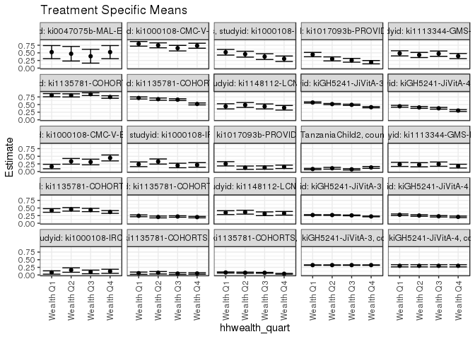

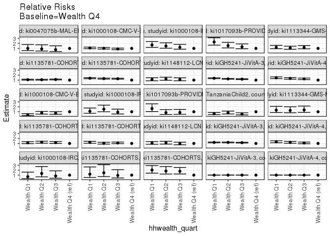

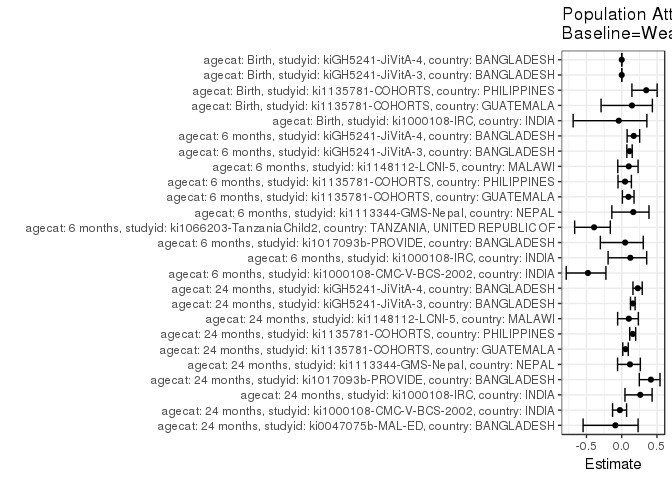

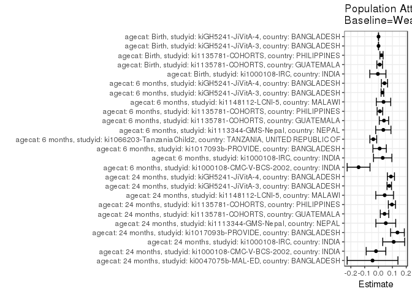

## Results Table

### Parameter: TSM

| agecat | studyid | country | intervention_level | baseline_level | estimate | ci_lower | ci_upper |
| --- | --- | --- | --- | --- | --- | --- | --- |
| Birth | ki1000108-IRC | INDIA | Wealth Q4 | NA | 0.1208791 | 0.0538154 | 0.1879429 |
| Birth | ki1000108-IRC | INDIA | Wealth Q1 | NA | 0.0816327 | 0.0273532 | 0.1359121 |
| Birth | ki1000108-IRC | INDIA | Wealth Q2 | NA | 0.1616162 | 0.0890131 | 0.2342192 |
| Birth | ki1000108-IRC | INDIA | Wealth Q3 | NA | 0.1000000 | 0.0411252 | 0.1588748 |
| Birth | ki1135781-COHORTS | GUATEMALA | Wealth Q4 | NA | 0.0492274 | 0.0245170 | 0.0739379 |
| Birth | ki1135781-COHORTS | GUATEMALA | Wealth Q1 | NA | 0.0584158 | 0.0217985 | 0.0950332 |
| Birth | ki1135781-COHORTS | GUATEMALA | Wealth Q2 | NA | 0.0725443 | 0.0323233 | 0.1127653 |
| Birth | ki1135781-COHORTS | GUATEMALA | Wealth Q3 | NA | 0.0462805 | 0.0172893 | 0.0752717 |
| Birth | ki1135781-COHORTS | PHILIPPINES | Wealth Q4 | NA | 0.0400158 | 0.0279803 | 0.0520514 |
| Birth | ki1135781-COHORTS | PHILIPPINES | Wealth Q1 | NA | 0.0808190 | 0.0626506 | 0.0989874 |
| Birth | ki1135781-COHORTS | PHILIPPINES | Wealth Q2 | NA | 0.0728896 | 0.0529806 | 0.0927987 |
| Birth | ki1135781-COHORTS | PHILIPPINES | Wealth Q3 | NA | 0.0709500 | 0.0561856 | 0.0857144 |
| Birth | kiGH5241-JiVitA-3 | BANGLADESH | Wealth Q4 | NA | 0.3233051 | 0.3156457 | 0.3309644 |
| Birth | kiGH5241-JiVitA-3 | BANGLADESH | Wealth Q1 | NA | 0.3233156 | 0.3156561 | 0.3309752 |
| Birth | kiGH5241-JiVitA-3 | BANGLADESH | Wealth Q2 | NA | 0.3233128 | 0.3156532 | 0.3309724 |
| Birth | kiGH5241-JiVitA-3 | BANGLADESH | Wealth Q3 | NA | 0.3233130 | 0.3156534 | 0.3309725 |
| Birth | kiGH5241-JiVitA-4 | BANGLADESH | Wealth Q4 | NA | 0.3004514 | 0.2648818 | 0.3360210 |
| Birth | kiGH5241-JiVitA-4 | BANGLADESH | Wealth Q1 | NA | 0.3003837 | 0.2648313 | 0.3359360 |
| Birth | kiGH5241-JiVitA-4 | BANGLADESH | Wealth Q2 | NA | 0.3003950 | 0.2648301 | 0.3359600 |
| Birth | kiGH5241-JiVitA-4 | BANGLADESH | Wealth Q3 | NA | 0.3004166 | 0.2648640 | 0.3359692 |
| 6 months | ki1000108-CMC-V-BCS-2002 | INDIA | Wealth Q4 | NA | 0.4449155 | 0.3477132 | 0.5421177 |
| 6 months | ki1000108-CMC-V-BCS-2002 | INDIA | Wealth Q1 | NA | 0.1638919 | 0.0902626 | 0.2375212 |
| 6 months | ki1000108-CMC-V-BCS-2002 | INDIA | Wealth Q2 | NA | 0.3347451 | 0.2420197 | 0.4274706 |
| 6 months | ki1000108-CMC-V-BCS-2002 | INDIA | Wealth Q3 | NA | 0.3128249 | 0.2202070 | 0.4054428 |
| 6 months | ki1000108-IRC | INDIA | Wealth Q4 | NA | 0.2156943 | 0.1395247 | 0.2918639 |
| 6 months | ki1000108-IRC | INDIA | Wealth Q1 | NA | 0.2374036 | 0.1610291 | 0.3137780 |
| 6 months | ki1000108-IRC | INDIA | Wealth Q2 | NA | 0.3282588 | 0.2441045 | 0.4124132 |
| 6 months | ki1000108-IRC | INDIA | Wealth Q3 | NA | 0.1980821 | 0.1240349 | 0.2721293 |
| 6 months | ki1017093b-PROVIDE | BANGLADESH | Wealth Q4 | NA | 0.1539089 | 0.0981197 | 0.2096980 |
| 6 months | ki1017093b-PROVIDE | BANGLADESH | Wealth Q1 | NA | 0.2534401 | 0.1829886 | 0.3238915 |

[output cut: 70 more lines]

### Parameter: E(Y)

| agecat | studyid | country | intervention_level | baseline_level | estimate | ci_lower | ci_upper |
| --- | --- | --- | --- | --- | --- | --- | --- |
| Birth | ki1000108-IRC | INDIA | NA | NA | 0.1159794 | 0.0840777 | 0.1478811 |
| Birth | ki1135781-COHORTS | GUATEMALA | NA | NA | 0.0575980 | 0.0416028 | 0.0735933 |
| Birth | ki1135781-COHORTS | PHILIPPINES | NA | NA | 0.0613316 | 0.0528136 | 0.0698496 |
| Birth | kiGH5241-JiVitA-3 | BANGLADESH | NA | NA | 0.3233133 | 0.3156536 | 0.3309730 |
| Birth | kiGH5241-JiVitA-4 | BANGLADESH | NA | NA | 0.3004866 | 0.2649179 | 0.3360553 |
| 6 months | ki1000108-CMC-V-BCS-2002 | INDIA | NA | NA | 0.3008130 | 0.2539566 | 0.3476694 |
| 6 months | ki1000108-IRC | INDIA | NA | NA | 0.2457002 | 0.2038248 | 0.2875757 |
| 6 months | ki1017093b-PROVIDE | BANGLADESH | NA | NA | 0.1617900 | 0.1318200 | 0.1917600 |
| 6 months | ki1066203-TanzaniaChild2 | TANZANIA, UNITED REPUBLIC OF | NA | NA | 0.0965347 | 0.0836528 | 0.1094165 |
| 6 months | ki1113344-GMS-Nepal | NEPAL | NA | NA | 0.2113677 | 0.1776128 | 0.2451225 |
| 6 months | ki1135781-COHORTS | GUATEMALA | NA | NA | 0.4086486 | 0.3769522 | 0.4403450 |
| 6 months | ki1135781-COHORTS | PHILIPPINES | NA | NA | 0.2112260 | 0.1958496 | 0.2266024 |
| 6 months | ki1148112-LCNI-5 | MALAWI | NA | NA | 0.3627451 | 0.3297365 | 0.3957537 |
| 6 months | kiGH5241-JiVitA-3 | BANGLADESH | NA | NA | 0.2514228 | 0.2432969 | 0.2595487 |
| 6 months | kiGH5241-JiVitA-4 | BANGLADESH | NA | NA | 0.2525156 | 0.2383895 | 0.2666417 |
| 24 months | ki0047075b-MAL-ED | BANGLADESH | NA | NA | 0.4805195 | 0.3681932 | 0.5928458 |
| 24 months | ki1000108-CMC-V-BCS-2002 | INDIA | NA | NA | 0.7150538 | 0.6691221 | 0.7609854 |
| 24 months | ki1000108-IRC | INDIA | NA | NA | 0.4156479 | 0.3678270 | 0.4634689 |
| 24 months | ki1017093b-PROVIDE | BANGLADESH | NA | NA | 0.3298611 | 0.2914318 | 0.3682904 |
| 24 months | ki1113344-GMS-Nepal | NEPAL | NA | NA | 0.4468938 | 0.4032281 | 0.4905594 |
| 24 months | ki1135781-COHORTS | GUATEMALA | NA | NA | 0.7909441 | 0.7661948 | 0.8156934 |
| 24 months | ki1135781-COHORTS | PHILIPPINES | NA | NA | 0.6167689 | 0.5974941 | 0.6360437 |
| 24 months | ki1148112-LCNI-5 | MALAWI | NA | NA | 0.4390244 | 0.3983906 | 0.4796582 |
| 24 months | kiGH5241-JiVitA-3 | BANGLADESH | NA | NA | 0.4907601 | 0.4776428 | 0.5038774 |
| 24 months | kiGH5241-JiVitA-4 | BANGLADESH | NA | NA | 0.3930960 | 0.3759134 | 0.4102786 |

### Parameter: RR

| agecat | studyid | country | intervention_level | baseline_level | estimate | ci_lower | ci_upper |
| --- | --- | --- | --- | --- | --- | --- | --- |
| Birth | ki1000108-IRC | INDIA | Wealth Q4 | Wealth Q4 | 1.0000000 | 1.0000000 | 1.0000000 |
| Birth | ki1000108-IRC | INDIA | Wealth Q1 | Wealth Q4 | 0.6753247 | 0.2840672 | 1.6054774 |
| Birth | ki1000108-IRC | INDIA | Wealth Q2 | Wealth Q4 | 1.3370064 | 0.6547919 | 2.7300066 |
| Birth | ki1000108-IRC | INDIA | Wealth Q3 | Wealth Q4 | 0.8272727 | 0.3683993 | 1.8577130 |
| Birth | ki1135781-COHORTS | GUATEMALA | Wealth Q4 | Wealth Q4 | 1.0000000 | 1.0000000 | 1.0000000 |
| Birth | ki1135781-COHORTS | GUATEMALA | Wealth Q1 | Wealth Q4 | 1.1866520 | 0.5313979 | 2.6498845 |
| Birth | ki1135781-COHORTS | GUATEMALA | Wealth Q2 | Wealth Q4 | 1.4736560 | 0.6973212 | 3.1142924 |
| Birth | ki1135781-COHORTS | GUATEMALA | Wealth Q3 | Wealth Q4 | 0.9401355 | 0.4214069 | 2.0973904 |
| Birth | ki1135781-COHORTS | PHILIPPINES | Wealth Q4 | Wealth Q4 | 1.0000000 | 1.0000000 | 1.0000000 |
| Birth | ki1135781-COHORTS | PHILIPPINES | Wealth Q1 | Wealth Q4 | 2.0196764 | 1.3942221 | 2.9257123 |
| Birth | ki1135781-COHORTS | PHILIPPINES | Wealth Q2 | Wealth Q4 | 1.8215196 | 1.2178151 | 2.7244971 |
| Birth | ki1135781-COHORTS | PHILIPPINES | Wealth Q3 | Wealth Q4 | 1.7730482 | 1.2357430 | 2.5439756 |
| Birth | kiGH5241-JiVitA-3 | BANGLADESH | Wealth Q4 | Wealth Q4 | 1.0000000 | 1.0000000 | 1.0000000 |
| Birth | kiGH5241-JiVitA-3 | BANGLADESH | Wealth Q1 | Wealth Q4 | 1.0000327 | 1.0000190 | 1.0000465 |
| Birth | kiGH5241-JiVitA-3 | BANGLADESH | Wealth Q2 | Wealth Q4 | 1.0000240 | 1.0000102 | 1.0000379 |
| Birth | kiGH5241-JiVitA-3 | BANGLADESH | Wealth Q3 | Wealth Q4 | 1.0000245 | 1.0000106 | 1.0000384 |
| Birth | kiGH5241-JiVitA-4 | BANGLADESH | Wealth Q4 | Wealth Q4 | 1.0000000 | 1.0000000 | 1.0000000 |
| Birth | kiGH5241-JiVitA-4 | BANGLADESH | Wealth Q1 | Wealth Q4 | 0.9997745 | 0.9991320 | 1.0004175 |
| Birth | kiGH5241-JiVitA-4 | BANGLADESH | Wealth Q2 | Wealth Q4 | 0.9998123 | 0.9991330 | 1.0004921 |
| Birth | kiGH5241-JiVitA-4 | BANGLADESH | Wealth Q3 | Wealth Q4 | 0.9998842 | 0.9992500 | 1.0005187 |
| 6 months | ki1000108-CMC-V-BCS-2002 | INDIA | Wealth Q4 | Wealth Q4 | 1.0000000 | 1.0000000 | 1.0000000 |
| 6 months | ki1000108-CMC-V-BCS-2002 | INDIA | Wealth Q1 | Wealth Q4 | 0.3683664 | 0.2233409 | 0.6075636 |
| 6 months | ki1000108-CMC-V-BCS-2002 | INDIA | Wealth Q2 | Wealth Q4 | 0.7523792 | 0.5284358 | 1.0712265 |
| 6 months | ki1000108-CMC-V-BCS-2002 | INDIA | Wealth Q3 | Wealth Q4 | 0.7031109 | 0.4868591 | 1.0154168 |
| 6 months | ki1000108-IRC | INDIA | Wealth Q4 | Wealth Q4 | 1.0000000 | 1.0000000 | 1.0000000 |
| 6 months | ki1000108-IRC | INDIA | Wealth Q1 | Wealth Q4 | 1.1006482 | 0.6894448 | 1.7571045 |
| 6 months | ki1000108-IRC | INDIA | Wealth Q2 | Wealth Q4 | 1.5218706 | 0.9915990 | 2.3357127 |
| 6 months | ki1000108-IRC | INDIA | Wealth Q3 | Wealth Q4 | 0.9183464 | 0.5528349 | 1.5255189 |
| 6 months | ki1017093b-PROVIDE | BANGLADESH | Wealth Q4 | Wealth Q4 | 1.0000000 | 1.0000000 | 1.0000000 |
| 6 months | ki1017093b-PROVIDE | BANGLADESH | Wealth Q1 | Wealth Q4 | 1.6466893 | 1.0426525 | 2.6006608 |

[output cut: 70 more lines]

### Parameter: PAR

| agecat | studyid | country | intervention_level | baseline_level | estimate | ci_lower | ci_upper |
| --- | --- | --- | --- | --- | --- | --- | --- |
| Birth | ki1000108-IRC | INDIA | Wealth Q4 | NA | -0.0048997 | -0.0632572 | 0.0534577 |
| Birth | ki1135781-COHORTS | GUATEMALA | Wealth Q4 | NA | 0.0083706 | -0.0120952 | 0.0288364 |
| Birth | ki1135781-COHORTS | PHILIPPINES | Wealth Q4 | NA | 0.0213158 | 0.0099890 | 0.0326425 |
| Birth | kiGH5241-JiVitA-3 | BANGLADESH | Wealth Q4 | NA | 0.0000082 | 0.0000051 | 0.0000113 |
| Birth | kiGH5241-JiVitA-4 | BANGLADESH | Wealth Q4 | NA | 0.0000352 | -0.0000929 | 0.0001634 |
| 6 months | ki1000108-CMC-V-BCS-2002 | INDIA | Wealth Q4 | NA | -0.1441024 | -0.2265711 | -0.0616338 |
| 6 months | ki1000108-IRC | INDIA | Wealth Q4 | NA | 0.0300059 | -0.0363111 | 0.0963229 |
| 6 months | ki1017093b-PROVIDE | BANGLADESH | Wealth Q4 | NA | 0.0078811 | -0.0405798 | 0.0563421 |
| 6 months | ki1066203-TanzaniaChild2 | TANZANIA, UNITED REPUBLIC OF | Wealth Q4 | NA | -0.0378272 | -0.0624405 | -0.0132139 |
| 6 months | ki1113344-GMS-Nepal | NEPAL | Wealth Q4 | NA | 0.0346370 | -0.0204096 | 0.0896836 |
| 6 months | ki1135781-COHORTS | GUATEMALA | Wealth Q4 | NA | 0.0391703 | 0.0054853 | 0.0728554 |
| 6 months | ki1135781-COHORTS | PHILIPPINES | Wealth Q4 | NA | 0.0099422 | -0.0101719 | 0.0300562 |
| 6 months | ki1148112-LCNI-5 | MALAWI | Wealth Q4 | NA | 0.0361170 | -0.0158541 | 0.0880882 |
| 6 months | kiGH5241-JiVitA-3 | BANGLADESH | Wealth Q4 | NA | 0.0280315 | 0.0184454 | 0.0376177 |
| 6 months | kiGH5241-JiVitA-4 | BANGLADESH | Wealth Q4 | NA | 0.0430066 | 0.0206760 | 0.0653372 |
| 24 months | ki0047075b-MAL-ED | BANGLADESH | Wealth Q4 | NA | -0.0432900 | -0.2266751 | 0.1400950 |
| 24 months | ki1000108-CMC-V-BCS-2002 | INDIA | Wealth Q4 | NA | -0.0182531 | -0.0890707 | 0.0525645 |
| 24 months | ki1000108-IRC | INDIA | Wealth Q4 | NA | 0.1094526 | 0.0303285 | 0.1885768 |
| 24 months | ki1017093b-PROVIDE | BANGLADESH | Wealth Q4 | NA | 0.1367020 | 0.0871495 | 0.1862546 |
| 24 months | ki1113344-GMS-Nepal | NEPAL | Wealth Q4 | NA | 0.0524192 | -0.0192857 | 0.1241241 |
| 24 months | ki1135781-COHORTS | GUATEMALA | Wealth Q4 | NA | 0.0432603 | 0.0127769 | 0.0737436 |
| 24 months | ki1135781-COHORTS | PHILIPPINES | Wealth Q4 | NA | 0.0967304 | 0.0708456 | 0.1226151 |
| 24 months | ki1148112-LCNI-5 | MALAWI | Wealth Q4 | NA | 0.0442787 | -0.0199014 | 0.1084588 |
| 24 months | kiGH5241-JiVitA-3 | BANGLADESH | Wealth Q4 | NA | 0.0774508 | 0.0613667 | 0.0935349 |
| 24 months | kiGH5241-JiVitA-4 | BANGLADESH | Wealth Q4 | NA | 0.0896051 | 0.0639572 | 0.1152530 |

### Parameter: PAF

| agecat | studyid | country | intervention_level | baseline_level | estimate | ci_lower | ci_upper |
| --- | --- | --- | --- | --- | --- | --- | --- |
| Birth | ki1000108-IRC | INDIA | Wealth Q4 | NA | -0.0422466 | -0.6888711 | 0.3568023 |
| Birth | ki1135781-COHORTS | GUATEMALA | Wealth Q4 | NA | 0.1453277 | -0.2927306 | 0.4349444 |
| Birth | ki1135781-COHORTS | PHILIPPINES | Wealth Q4 | NA | 0.3475495 | 0.1444595 | 0.5024296 |
| Birth | kiGH5241-JiVitA-3 | BANGLADESH | Wealth Q4 | NA | 0.0000254 | 0.0000159 | 0.0000349 |
| Birth | kiGH5241-JiVitA-4 | BANGLADESH | Wealth Q4 | NA | 0.0001172 | -0.0003097 | 0.0005438 |
| 6 months | ki1000108-CMC-V-BCS-2002 | INDIA | Wealth Q4 | NA | -0.4790433 | -0.7871642 | -0.2240448 |
| 6 months | ki1000108-IRC | INDIA | Wealth Q4 | NA | 0.1221242 | -0.1931883 | 0.3541120 |
| 6 months | ki1017093b-PROVIDE | BANGLADESH | Wealth Q4 | NA | 0.0487122 | -0.3029538 | 0.3054638 |
| 6 months | ki1066203-TanzaniaChild2 | TANZANIA, UNITED REPUBLIC OF | Wealth Q4 | NA | -0.3918508 | -0.6674714 | -0.1617883 |
| 6 months | ki1113344-GMS-Nepal | NEPAL | Wealth Q4 | NA | 0.1638709 | -0.1400904 | 0.3867925 |
| 6 months | ki1135781-COHORTS | GUATEMALA | Wealth Q4 | NA | 0.0958533 | 0.0094909 | 0.1746857 |
| 6 months | ki1135781-COHORTS | PHILIPPINES | Wealth Q4 | NA | 0.0470688 | -0.0526433 | 0.1373356 |
| 6 months | ki1148112-LCNI-5 | MALAWI | Wealth Q4 | NA | 0.0995658 | -0.0556516 | 0.2319609 |
| 6 months | kiGH5241-JiVitA-3 | BANGLADESH | Wealth Q4 | NA | 0.1114916 | 0.0726933 | 0.1486667 |
| 6 months | kiGH5241-JiVitA-4 | BANGLADESH | Wealth Q4 | NA | 0.1703126 | 0.0767955 | 0.2543568 |
| 24 months | ki0047075b-MAL-ED | BANGLADESH | Wealth Q4 | NA | -0.0900901 | -0.5479021 | 0.2323181 |
| 24 months | ki1000108-CMC-V-BCS-2002 | INDIA | Wealth Q4 | NA | -0.0255269 | -0.1296357 | 0.0689871 |
| 24 months | ki1000108-IRC | INDIA | Wealth Q4 | NA | 0.2633301 | 0.0459807 | 0.4311619 |
| 24 months | ki1017093b-PROVIDE | BANGLADESH | Wealth Q4 | NA | 0.4144230 | 0.2495423 | 0.5430783 |
| 24 months | ki1113344-GMS-Nepal | NEPAL | Wealth Q4 | NA | 0.1172968 | -0.0588505 | 0.2641407 |
| 24 months | ki1135781-COHORTS | GUATEMALA | Wealth Q4 | NA | 0.0546945 | 0.0151152 | 0.0926832 |
| 24 months | ki1135781-COHORTS | PHILIPPINES | Wealth Q4 | NA | 0.1568340 | 0.1136865 | 0.1978810 |
| 24 months | ki1148112-LCNI-5 | MALAWI | Wealth Q4 | NA | 0.1008570 | -0.0580065 | 0.2358666 |
| 24 months | kiGH5241-JiVitA-3 | BANGLADESH | Wealth Q4 | NA | 0.1578180 | 0.1245392 | 0.1898318 |
| 24 months | kiGH5241-JiVitA-4 | BANGLADESH | Wealth Q4 | NA | 0.2279471 | 0.1593613 | 0.2909371 |